# Linear Regression

Roger Geertz Gonzalez

July 10, 2020

## Import the Data

Import the data from the Dutch Lexicon Project `DLP_words.csv`. All materials are from here: http://crr.ugent.be/programs-data/lexicon-projects

Variables we are going to use: - `rt`: Response Latency to the Lexical Decision Task - `subtlex.frequency`: The frequency of the word from the Dutch Subtitle Project. - `length`: Length of the word. - `POS`: part of speech. - `bigram.freq`: Summed frequency of the bigrams in the word (the sum of each two-letter combination frequency).

```r
library(readr)
dlp <- read_csv("DLP_words.csv")
```

## Load the Libraries + Functions

Load all the libraries or functions that you will use to for the rest of the assignment. It is helpful to define your libraries and functions at the top of a report, so that others can know what they need for the report to compile correctly.

```r
library(car)
library(carData)
library(Rling)
```

## Clean Up Part of Speech

Update the part of speech variable so that the Nouns are the comparison category. Here’s what the labels mean:

ADJ - Adjective N - Noun WW - Verbs

```r
table(dlp$POS)
```

```
##
##  ADJ    N   WW
## 1397 7591 3038
```

```r
dlp$POS = factor(dlp$POS, #the column you want to update
                 #the values in the data in the order you want
                 levels = c("N", "ADJ", "WW"),
                 #give them better labels if you want
                 labels = c("Noun", "Adjective", "Verb"))

table(dlp$POS)
```

```
##
##      Noun Adjective      Verb
##      7591      1397      3038
```

## Deal with Non-Normality

Since we are using frequencies, we should consider the non-normality of frequency. - Include a histogram of the original `subtlex.frequency` column. - Log-transform the `subtlex.frequency` column. - Include a histogram of `bigram.freq` - note that it does not appear extremely skewed.

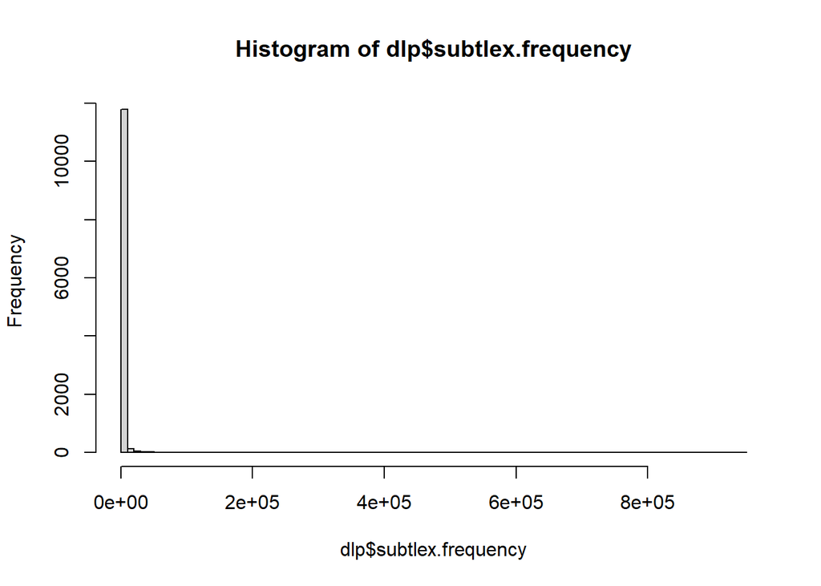

```r
hist(dlp$subtlex.frequency, breaks = 100)
```

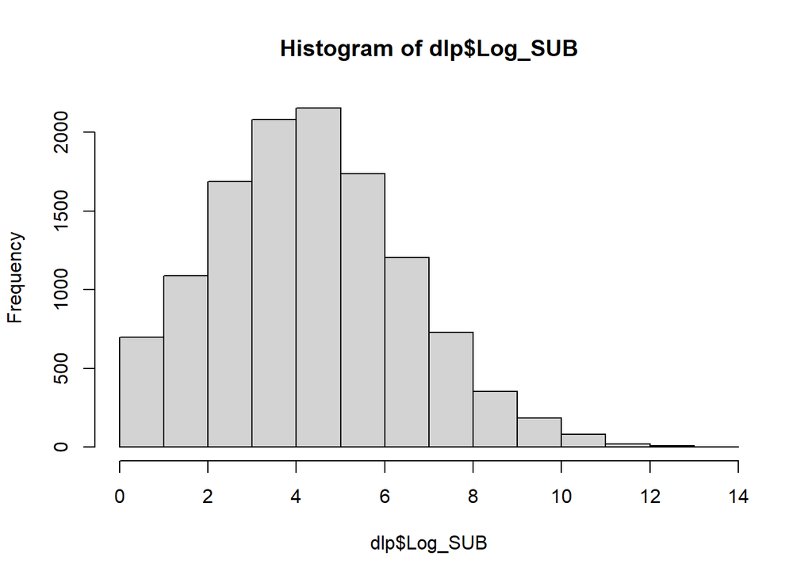

```r
dlp$Log_SUB = log(dlp$subtlex.frequency)
hist(dlp$Log_SUB)
```

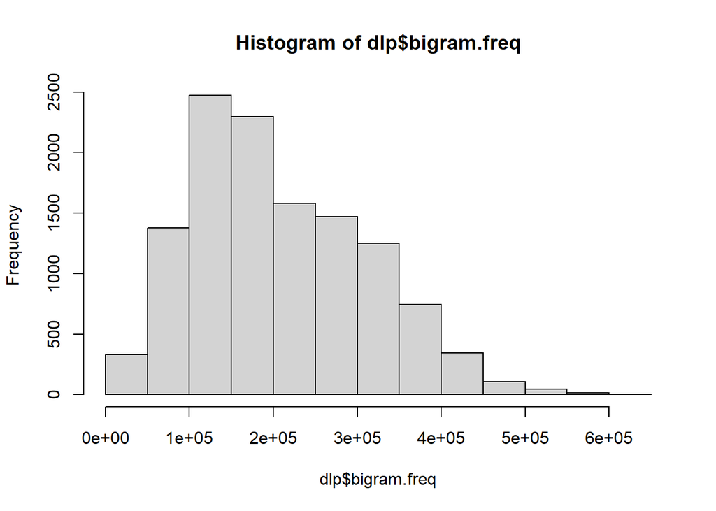

```r
hist(dlp$bigram.freq)
```

## Create Your Linear Model

See if you can predict response latencies (DV) with the following IVs: subtitle frequency, length, POS, and bigram frequency.

```r
model = lm(rt ~ Log_SUB + length + POS+bigram.freq,
data = dlp)
```

## Interpret Your Model

### Coefficients

- Which coefficients are statistically significant?
- What do they suggest predicts response latency? (i.e., give the non-stats interpretation of the coefficients)
- Which coefficients appear to predict the most variance? Calculate the $pr^2$ values below:

```r
summary(model)
```

```
##
## Call:
## lm(formula = rt ~ Log_SUB + length + POS + bigram.freq, data = dlp)
##
## Residuals:
##     Min      1Q  Median      3Q     Max
## -348.88  -33.85   -6.19   27.49  616.60
##
## Coefficients:
##                Estimate Std. Error t value Pr(>|t|)
## (Intercept)   7.112e+02  2.520e+00 282.176  < 2e-16 ***
## Log_SUB      -1.808e+01  2.253e-01 -80.218  < 2e-16 ***
## length       -1.806e+00  3.486e-01  -5.180 2.26e-07 ***
## POSAdjective  7.976e+00  1.486e+00   5.368 8.13e-08 ***
## POSVerb       1.170e+01  1.157e+00  10.119  < 2e-16 ***
## bigram.freq   3.374e-05  5.246e-06   6.432 1.31e-10 ***
## ---
## Signif. codes:  0 '***' 0.001 '**' 0.01 '*' 0.05 '.' 0.1 ' ' 1
##
## Residual standard error: 50.76 on 12009 degrees of freedom
##   (11 observations deleted due to missingness)
## Multiple R-squared:   0.37,  Adjusted R-squared:  0.3697
## F-statistic:  1410 on 5 and 12009 DF,  p-value: < 2.2e-16
```

```r
summary(model$residuals)
```

```
##     Min.  1st Qu.   Median     Mean  3rd Qu.     Max.
## -348.879  -33.850   -6.189    0.000   27.489  616.596
```

```r
options(scipen = 999)
t <- summary(model)$coefficients[-1 , 3]
pr <- t / sqrt(t^2 + model$df.residual)
pr^2
```

```
##      Log_SUB       length POSAdjective      POSVerb  bigram.freq
##  0.348893207  0.002229149  0.002393353  0.008453925  0.003432757
```

- What do the dummy coded POS values mean? Calculate the means of each group below to help you interpret:

```r
tapply(dlp$rt, #dv
       dlp$POS, #iv group variable
       mean, na.rm=TRUE) #function
```

```
##      Noun Adjective      Verb
##  633.1077  628.9087  633.5708
```

### Overall Model

- Is the overall model statistically significant?
- What is the practical importance of the overall model?

## Diagnostic Tests

### Outliers

Create an influence plot of the model using the `car` library. - Which data points appear to have the most influence on the model?

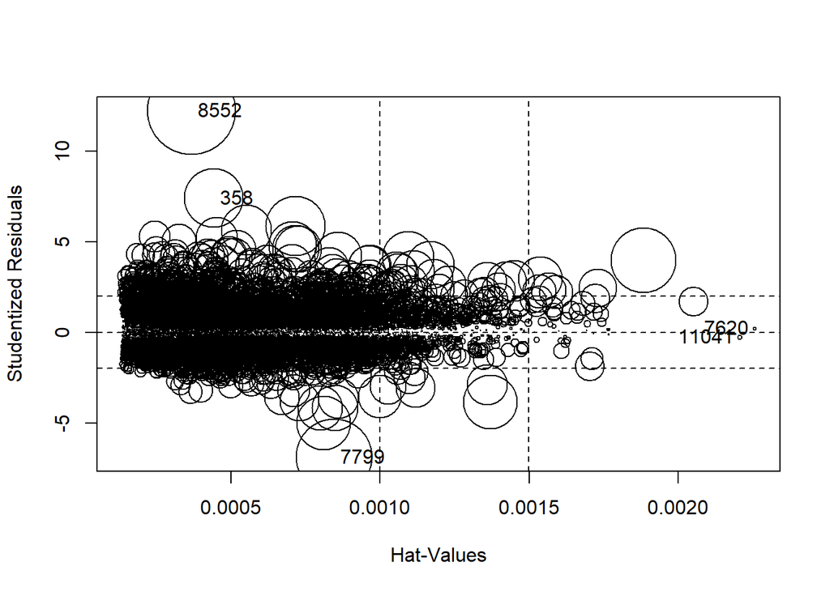

```
##          StudRes          Hat         CookD
## 358    7.4011293 0.0004432197 0.00403010022
## 7620   0.2091906 0.0022564015 0.00001649549
## 7799  -6.8894657 0.0008468915 0.00667941519
## 8552  12.2246554 0.0003687713 0.00907619766
## 11041 -0.2678347 0.0022063720 0.00002643955
```

```r
influencePlot(model)
```

```r
dlp[c(358, 7620, 7799), ]
```

```
## # A tibble: 3 x 8
##   spelling   lexicality    rt subtlex.frequen~ length POS    bigram.freq Log_SUB
##   <chr>      <chr>      <dbl>            <dbl>  <dbl> <fct>        <dbl>   <dbl>
## 1 bats       W          1033                15      4 Noun         95596    2.71
## 2 rechtstre~ W           605.              567     12 Adjec~      338480    6.34
## 3 riks       W           358                 1      4 Noun         86017    0
```

### Additivity

Do we have additivity in our model? - Show that the correlations between predictors is less than .9. - Show the VIF values.

```r
## correlation
summary(model, correlation= TRUE)$correlation[-1, -1]
```

```
##                  Log_SUB       length POSAdjective     POSVerb bigram.freq
## Log_SUB       1.00000000  0.300651186 -0.090366305 -0.14697353 -0.02461407
## length        0.30065119  1.000000000 -0.001602351  0.05451139 -0.42378059
## POSAdjective -0.09036631 -0.001602351  1.000000000  0.20576650  0.01590674
## POSVerb      -0.14697353  0.054511388  0.205766502  1.00000000 -0.29582267
## bigram.freq  -0.02461407 -0.423780585  0.015906745 -0.29582267  1.00000000
```

```r
## VIF
vif(model)
```

```
##                 GVIF Df GVIF^(1/(2*Df))
## Log_SUB     1.143764  1        1.069469
## length      1.362545  1        1.167281
## POS         1.139962  2        1.033291
## bigram.freq 1.358598  1        1.165589
```

### Linearity

Is the model linear? - Include a plot and interpret the output.

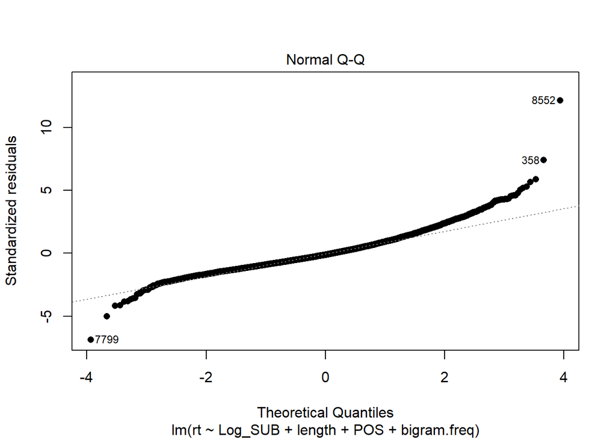

```r
plot(model, which = 2, pch = 16)
```

### Normality

Are the errors normally distributed? - Include a plot and interpret the output.

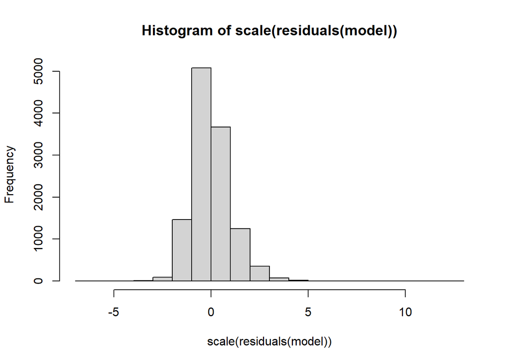

```r
hist(scale(residuals(model)))
```

### Homoscedasticity/Homogeneity

Do the errors meet the assumptions of homoscedasticity and homogeneity? - Include a plot and interpret the output (either plot option).

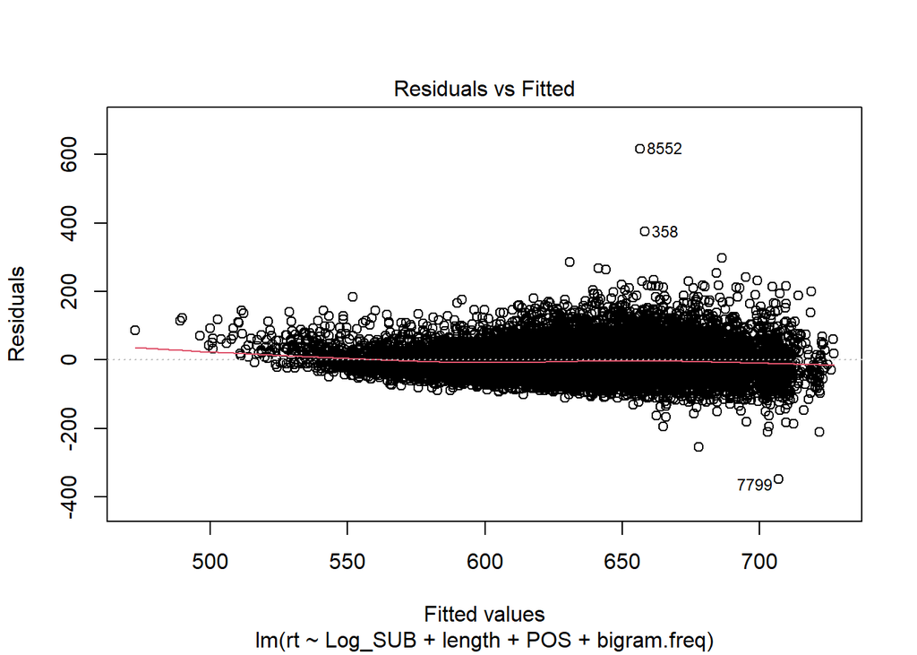

```r
plot(model, which = 1)
```

### Bootstrapping

Use the function provided from class (included below) and the `boot` library to bootstrap the model you created 1000 times. - Include the estimates of the coefficients from the bootstrapping. - Include the confidence intervals for at least one of the predictors (not the intercept). - Do our estimates appear stable, given the bootstrapping results?

Use the following to randomly sample 500 rows of data - generally, you have to have more bootstraps than rows of data, so this code will speed up your assignment. In the `boot` function use: `data = DF[sample(1:nrow(DF), 500, replace=FALSE),]` for the data argument changing DF to the name of your data frame.

```r
library(boot)
bootcoef = function(formula, data, indices){
  d = data[indices, ] #randomize the data by row
  model = lm(formula, data = d) #run our model
  return(coef(model)) #give back coefficients
}

# The estimates of the coefficients from the bootstrapping
bootmodel <- boot(formula = rt ~ subtlex.frequency + length + POS + bigram.freq,
                    data = dlp[sample(1:nrow(dlp), size = 500, replace = FALSE), ],
                    statistic = bootcoef,
                    R = 1000)
bootmodel
```

```
##
## ORDINARY NONPARAMETRIC BOOTSTRAP
##
##
## Call:
## boot(data = dlp[sample(1:nrow(dlp), size = 500, replace = FALSE),
##     ], statistic = bootcoef, R = 1000, formula = rt ~ subtlex.frequency +
##     length + POS + bigram.freq)
##
##
## Bootstrap Statistics :
##             original             bias       std. error
## t1* 595.617287369352  1.585157515327523 13.53914502025
## t2*  -0.000080139358 -0.000870267981411  0.00179659656
## t3*   5.554652612939 -0.218547151812727  2.23636867661
## t4*  11.287002497416  1.179210799804384  9.66416903212
## t5*  -2.945854920969  0.930125103295616  6.64601474258
## t6*   0.000009398078 -0.000000002106214  0.00003356111
```

```r
boot.ci(bootmodel, index = 3)
```

```
## BOOTSTRAP CONFIDENCE INTERVAL CALCULATIONS
## Based on 1000 bootstrap replicates
##
## CALL :
## boot.ci(boot.out = bootmodel, index = 3)
##
## Intervals :
## Level      Normal              Basic
## 95%   ( 1.390, 10.156 )   ( 1.020, 10.252 )
##
## Level     Percentile            BCa
## 95%   ( 0.858, 10.089 )   ( 1.485, 10.704 )
## Calculations and Intervals on Original Scale
```